# Union

Topics that will be discussed in this summary report for Union County are

- Demographic Characteristics
  - Population growth from 1970 to 2020;
  - population density
  - sex, race, and age
  - educational level of the adult population
  - housing characteristics in terms of age of the housing stock and type of tenure
- Economic Characteristics
  - family income, household income, per capita income,
  - poverty status of families;
  - employment classification according to industry;
  - labor force by place of work and commuting patterns;

For more details on the data used, please see the Data Description tab.

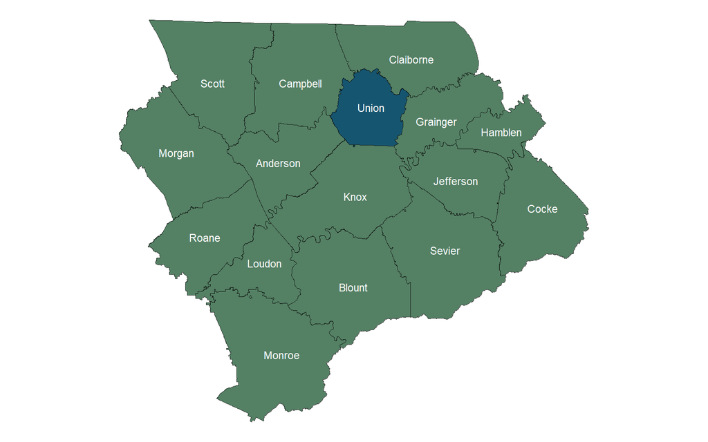

**Population and Growth**

| Place | 1970 | 1980 | 1990 | 2000 | 2010 | 2020 | Change 1970-1980 | Change 1980-1990 | Change 1990-2000 | Change 2000-2010 | Change 2010-2020 |
| --- | --- | --- | --- | --- | --- | --- | --- | --- | --- | --- | --- |
| Union County | 9072 | 11707 | 13694 | 17808 | 19109 | 19802 | 2635 | 1987 | 4114 | 1301 | 693 |
| Luttrell |  | 962 | 812 | 915 | 1074 | 1017 |  | -150 | 103 | 159 | -57 |
| Maynardville |  | 924 | 1298 | 1782 | 2413 | 2456 |  | 374 | 484 | 631 | 43 |
| Plainview |  |  |  | 1866 | 2125 | 2060 |  |  |  | 259 | -65 |

[interactive chart not shown]

IPUMS NHGIS, University of Minnesota, www.nhgis.org

**Population Density**

| Place | Area | Population Density |
| --- | --- | --- |
| Union County | 247.0842474071373 | 80.14270520196666 |
| Luttrell | 3.930388172297815 | 258.7530685055551 |
| Maynardville | 5.392854348987814 | 455.417454480477 |
| Plainview | 6.367260149101898 | 323.5300508791938 |

[interactive chart not shown]

source: U. S. Census Bureau *Decennial Census: Redistricting Data (PL 94-171)*, 2020, accessed June 2, 2026, http://api.census.gov/data/2020/dec/pl.

**Population Descriptions**

| Place | Year | Race Category | Number of People | Percentage of People |
| --- | --- | --- | --- | --- |
| Union County | 2020 | Black | 53 | 0.002091967633708309 |
| Union County | 2020 | Other | 979 | 0.03864219459246102 |
| Union County | 2020 | White | 18770 | 0.7408723110321689 |
| Luttrell | 2020 | Black | 9 | 0.0003552397868561279 |
| Luttrell | 2020 | Other | 84 | 0.003315571343990527 |
| Luttrell | 2020 | White | 924 | 0.0364712847838958 |
| Maynardville | 2020 | Black | 5 | 0.0001973554371422933 |
| Maynardville | 2020 | Other | 175 | 0.006907440299980265 |
| Maynardville | 2020 | White | 2276 | 0.0898361949871719 |
| Plainview | 2020 | Black | 10 | 0.0003947108742845866 |

[output cut: 2 more lines]

| Place | Sex | Age Range | Year | Number of People | Percentage of People |
| --- | --- | --- | --- | --- | --- |
| Union County | Female | 10 to 14 years | 2020 | 773 | 0.0304378642305875 |
| Union County | Female | 15 to 19 years | 2020 | 564 | 0.02220822176720743 |
| Union County | Female | 20 to 24 years | 2020 | 498 | 0.01960938730508742 |
| Union County | Female | 25 to 29 years | 2020 | 591 | 0.0232713813198929 |
| Union County | Female | 30 to 34 years | 2020 | 586 | 0.02307449992124744 |
| Union County | Female | 35 to 39 years | 2020 | 612 | 0.02409828319420381 |
| Union County | Female | 40 to 44 years | 2020 | 631 | 0.02484643250905655 |
| Union County | Female | 45 to 49 years | 2020 | 661 | 0.02602772090092928 |
| Union County | Female | 5 to 9 years | 2020 | 462 | 0.01819184123484013 |
| Union County | Female | 50 to 54 years | 2020 | 727 | 0.0286265553630493 |

[output cut: 134 more lines]

[interactive chart not shown]

source: U. S. Census Bureau *Decennial Census: Redistricting Data (PL 94-171)*, 2020, accessed June 2, 2026, http://api.census.gov/data/2020/dec/pl.

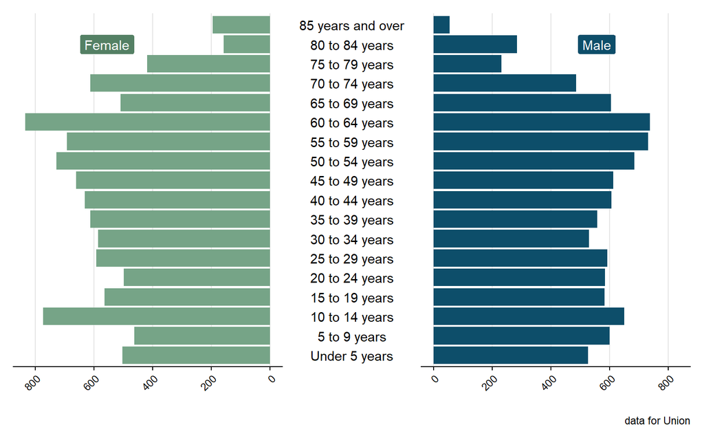

source: U. S. Census Bureau *American Community Survey 5-Year Estimates: Comparison Profiles 5-Year*, 2020, accessed June 2, 2026, http://api.census.gov/data/2020/acs/acs5.

**Education**

| Place | Level of Education | Year | Number of People | Percentage of People |
| --- | --- | --- | --- | --- |
| Union County | 9th to 12th Grade, No Diploma | 2010 | 1774 | 0.1067452915337866 |
| Union County | Associate's degree | 2010 | 650 | 0.0391118599193694 |
| Union County | Bachelor's degree | 2010 | 544 | 0.032733618147903 |
| Union County | Graduate or Professional Degree | 2010 | 265 | 0.01594560442866598 |
| Union County | Less Than 9th Grade | 2010 | 2343 | 0.1409832119862808 |
| Union County | Some College, No Degree | 2010 | 1687 | 0.1015103195138095 |
| Union County | Total | 2010 | 12931 | 0.7780853240267164 |
| Union County | 9th to 12th Grade, No Diploma | 2020 | 1336 | 0.07427173671336447 |
| Union County | Associate's degree | 2020 | 1242 | 0.06904603068712475 |
| Union County | Bachelor's degree | 2020 | 822 | 0.0456971314209473 |

[output cut: 46 more lines]

[interactive chart not shown]

source: U. S. Census Bureau *American Community Survey 5-Year Estimates: Comparison Profiles 5-Year*, 2020, accessed June 2, 2026, http://api.census.gov/data/2020/acs/acs5.

**Housing Units by Year of Construction**

| Place | Year | 1939 or earlier | 1940-1959 | 1960-1979 | 1980 to 1989 | 1990 to 1999 | 2000 to 2004 | 2005 or later | 2000 to 2009 | 2010 or later | Total |
| --- | --- | --- | --- | --- | --- | --- | --- | --- | --- | --- | --- |
| Union County | 2010 | 318 | 1094 | 2512 | 1811 | 2134 | 805 | 229 |  |  | 8903 |
| Union County | 2020 | 370 | 573 | 2044 | 1306 | 2245 |  |  | 2229 | 720 | 9487 |
| Luttrell | 2010 | 47 | 43 | 115 | 99 | 93 | 41 | 0 |  |  | 438 |
| Maynardville | 2010 | 78 | 100 | 283 | 179 | 217 | 139 | 22 |  |  | 1018 |
| Plainview | 2010 | 16 | 42 | 253 | 124 | 289 | 82 | 68 |  |  | 874 |
| Luttrell | 2020 | 12 | 70 | 84 | 62 | 133 |  |  | 73 | 54 | 488 |
| Maynardville | 2020 | 27 | 45 | 164 | 257 | 263 |  |  | 412 | 20 | 1188 |
| Plainview | 2020 | 76 | 30 | 189 | 158 | 294 |  |  | 218 | 17 | 982 |

[interactive chart not shown]

source: U. S. Census Bureau *Decennial Census: Redistricting Data (PL 94-171)*, 2020, accessed June 2, 2026, http://api.census.gov/data/2020/dec/pl.

**Housing Units by Type of Tenure**

| Place | Year | Own | Rent | Total |
| --- | --- | --- | --- | --- |
| Union County | 2010 | 5944 | 1446 | 7390 |
| Union County | 2020 | 5621 | 1842 | 7463 |
| Luttrell | 2010 | 279 | 104 | 383 |
| Maynardville | 2010 | 516 | 355 | 871 |
| Plainview | 2010 | 725 | 119 | 844 |
| Luttrell | 2020 | 302 | 106 | 408 |
| Maynardville | 2020 | 561 | 424 | 985 |
| Plainview | 2020 | 645 | 233 | 878 |

[interactive chart not shown]

source: U. S. Census Bureau *Decennial Census: Redistricting Data (PL 94-171)*, 2020, accessed June 2, 2026, http://api.census.gov/data/2020/dec/pl.

**Income Comparison**

| Place | Year | Median Family Income | Median Household Income | Per Capita Income |
| --- | --- | --- | --- | --- |
| Union County | 2020 | 53013 | 45143 | 24268 |
| Luttrell | 2020 | 33536 | 31887 | 20925 |
| Maynardville | 2020 | 42232 | 40402 | 20039 |
| Plainview | 2020 | 53701 | 44141 | 21341 |

[interactive chart not shown]

source: U. S. Census Bureau *Decennial Census: Redistricting Data (PL 94-171)*, 2020, accessed June 2, 2026, http://api.census.gov/data/2020/dec/pl.

**Povery Status**

| Place | Year | Above Poverty | Below Poverty |
| --- | --- | --- | --- |
| Union County | 2020 | 4770 | 949 |
| Luttrell | 2020 | 250 | 51 |
| Maynardville | 2020 | 453 | 112 |
| Plainview | 2020 | 566 | 106 |

[interactive chart not shown]

source: U. S. Census Bureau *American Community Survey 5-Year Estimates: Comparison Profiles 5-Year*, 2020, accessed June 2, 2026, http://api.census.gov/data/2020/acs/acs5.

**Poverty Status by Family Type**

| Place | Poverty Status | Family Type | Number of Families | Year | Percentage of Families |
| --- | --- | --- | --- | --- | --- |
| Union County | Above Poverty | All Families | 4770 | 2020 | 0.6572964034725093 |
| Union County | Above Poverty | Female Householder | 602 | 2020 | 0.08295438886592256 |
| Union County | Above Poverty | Female Householder with related children | 190 | 2020 | 0.02618161774838087 |
| Union County | Below Poverty | All Families | 949 | 2020 | 0.130770290753755 |
| Union County | Below Poverty | Female Householder | 420 | 2020 | 0.05787515502273667 |
| Union County | Below Poverty | Female Householder with related children | 398 | 2020 | 0.05484359928345046 |
| Luttrell | Above Poverty | All Families | 250 | 2020 | 0.03444949703734326 |
| Luttrell | Above Poverty | Female Householder | 63 | 2020 | 0.0086812732534105 |
| Luttrell | Above Poverty | Female Householder with related children | 3 | 2020 | 0.000413393964448119 |
| Luttrell | Below Poverty | All Families | 51 | 2020 | 0.007027697395618024 |

[output cut: 14 more lines]

[interactive chart not shown]

source: U. S. Census Bureau *American Community Survey 5-Year Estimates: Comparison Profiles 5-Year*, 2020, accessed June 2, 2026, http://api.census.gov/data/2020/acs/acs5.

**Employment by Industry**

[output not shown]

[output cut: 34 more lines]

[interactive chart not shown]

source: U. S. Census Bureau *American Community Survey 5-Year Estimates: Comparison Profiles 5-Year*, 2020, accessed June 2, 2026, http://api.census.gov/data/2020/acs/acs5.

**Employment by Industry (Historical)**

| Place | Year | Industry | Number of Jobs | Percentage of Jobs |
| --- | --- | --- | --- | --- |
| Luttrell | 2010 | Agriculture, Forestry, Fishing And Hunting, And Mining | 23 | 0.002339538195504018 |
| Luttrell | 2010 | Construction | 27 | 0.00274641440341776 |
| Luttrell | 2010 | Manufacturing | 122 | 0.01240972434136914 |
| Luttrell | 2010 | Other | 7 | 0.0007120333638490489 |
| Luttrell | 2010 | Professional Services | 148 | 0.01505441969280846 |
| Luttrell | 2010 | Public Administration | 4 | 0.0004068762079137422 |
| Luttrell | 2010 | Trade, Finance, Insurance &amp; Real Estate | 92 | 0.009358152782016071 |
| Luttrell | 2020 | Agriculture, Forestry, Fishing And Hunting, And Mining | 11 | 0.001084812623274162 |
| Luttrell | 2020 | Construction | 108 | 0.0106508875739645 |
| Luttrell | 2020 | Manufacturing | 47 | 0.004635108481262327 |

[output cut: 46 more lines]

**Labor Force by Place of Work**

| Place | Year | Work Out Of State | Work Out of County of Residence | Work in County of Residence |
| --- | --- | --- | --- | --- |
| Union County | 2020 | 141 | 4717 | 2852 |
| Luttrell | 2020 | 27 | 244 | 61 |
| Maynardville | 2020 | 0 | 597 | 386 |
| Plainview | 2020 | 17 | 826 | 122 |

[interactive chart not shown]

source: U. S. Census Bureau *American Community Survey 5-Year Estimates: Comparison Profiles 5-Year*, 2020, accessed June 2, 2026, http://api.census.gov/data/2020/acs/acs5.

**Commuting Patterns**

| Home County | Year | Number of Jobs | Percentage of Jobs |
| --- | --- | --- | --- |
| Union | 2010 | 1074 | 0.2404836542767577 |
| Union | 2020 | 902 | 0.2019704433497537 |
| Knox | 2020 | 487 | 0.1090461262875056 |
| Knox | 2010 | 425 | 0.09516345723242275 |
| Claiborne | 2020 | 130 | 0.02910882221227049 |
| Claiborne | 2010 | 129 | 0.02888490819525302 |
| Anderson | 2020 | 79 | 0.01768920734437976 |
| Anderson | 2010 | 56 | 0.01253918495297806 |
| Blount | 2020 | 41 | 0.009180474697716077 |
| Blount | 2010 | 34 | 0.00761307657859382 |

[output cut: 3 more lines]

| Work County | Year | Number of Jobs | Percentage of Jobs |
| --- | --- | --- | --- |
| Knox | 2020 | 3462 | 0.7751903269144649 |
| Knox | 2010 | 3317 | 0.7427227944469323 |
| Union | 2010 | 1074 | 0.2404836542767577 |
| Union | 2020 | 902 | 0.2019704433497537 |
| Claiborne | 2020 | 285 | 0.0638154948499776 |
| Claiborne | 2010 | 250 | 0.05597850425436632 |
| Campbell | 2020 | 106 | 0.02373488580385132 |
| Campbell | 2010 | 89 | 0.01992834751455441 |
| Grainger | 2020 | 89 | 0.01992834751455441 |
| Grainger | 2010 | 68 | 0.01522615315718764 |

[output cut: 3 more lines]

[interactive chart not shown]

source: U. S. Census Bureau *Tn_od_main_JT00_2020*, LEHD Origin-Destination Employment Statistics, 8.3, 2020, accessed June 2, 2026, https://lehd.ces.census.gov/data/lodes/.

## References

Bureau, U. S. Census. *American Community Survey 5-Year Estimates: Comparison Profiles 5-Year*. 2020. Accessed June 2, 2026. http://api.census.gov/data/2020/acs/acs5.

Bureau, U. S. Census. *Decennial Census: Redistricting Data (PL 94-171)*. 2020. Accessed June 2, 2026. http://api.census.gov/data/2020/dec/pl.

Bureau, U. S. Census. *Tn_od_main_JT00_2020*. LEHD Origin-Destination Employment Statistics, 8.3. 2020. Accessed June 2, 2026. https://lehd.ces.census.gov/data/lodes/.